# Can we predict one’s biological age?

Ridge, LASSO, and Elastic-Net regression

Joao Malato

Nuno Sepulveda

September 16th, 2022

# Libraries

```r
library(here)       # easy directory management, as here("YOUR/FILE/PATH")
library(data.table) # fast data wrangling
library(magrittr)   # use of pipe operator `%>%`
library(ggplot2)    # graphics
library(nortest)    # normality assessment test
library(glmnet)     # penalised regression models
```

# Load data

Still using the same subset of whole blood data from 656 human individuals, made available by [Hannun et al. (2013)](https://www.sciencedirect.com/science/article/pii/S1097276512008933?via%3Dihub).

```r
# base R
# mdna <- read.csv(here("data/methDNA_data_Hannun_etal_2013_2.csv"), header = TRUE)
mdna_logodds <- read.csv(here("data/logodds_methDNA_data_Hannun_etal_2013.csv"), header = TRUE)
```

```r
# look at first 8 cols from the data
head(mdna_logodds[, 1:8])
```

```
##      GEO.ID Age Gender Ethnicity cg17568996 cg02245378 cg14093936 cg15642326
## 1 GSM989827  67      F Caucasian  -2.422868  -2.319565 -0.7094626 -1.0117542
## 2 GSM989828  89      F Caucasian  -2.698340  -2.202109 -0.9977517 -1.0850560
## 3 GSM989829  66      F Caucasian  -1.984273  -2.164124 -0.7462700 -1.1361828
## 4 GSM989830  64      F Caucasian  -2.228179  -2.315447 -0.6371883 -0.9794073
## 5 GSM989831  62      F Caucasian  -1.969918  -2.246539 -0.6202693 -0.9264593
## 6 GSM989832  87      F Caucasian  -1.388692  -1.632925 -0.5858540 -1.3271837
```

Variables:

```r
# binary variables to factors with defined reference
mdna_logodds$Gender <- relevel(factor(mdna_logodds$Gender), ref = "F")
mdna_logodds$Ethnicity <- relevel(factor(mdna_logodds$Ethnicity), ref = "Caucasian")
```

```r
# get a vector with all column names with their pattern starting with "cg" (i.e., the names of all CpG probes)
vec_probe <- grep("^cg", colnames(mdna_logodds), value = TRUE)

# ordered by correlation with age
vec_cor_values <- sapply(seq(vec_probe), function(x) cor(mdna_logodds$Age, mdna_logodds[, vec_probe[x]], method = "spearman"))
# save the CpG probes ordered by their absolute correlation value
vec_probe_cor <- vec_probe[order(abs(vec_cor_values), decreasing = TRUE)]
```

# Penalized regression

For this section you will be using the [*glmnet*](https://cloud.r-project.org/web/packages/glmnet/index.html) package. This is but an introduction to an versatile package that is used to fit Ridge, LASSO or Elastic-Net paths to more than just linear regression.

How to distinguish between Ridge and LASSO regression in R:

In the provided formulas we can define the type of regression we want, depending on the tuning parameter $\lambda$ used, as $\lambda_1$ for LASSO and $\lambda_2$ for Ridge, respectively. Instead of using two different arguments for $\lambda$, the *glmnet* functions (`glmnet()` and the `cv.glmnet()`) define an Elastic-Net penalty parameter/argument, $\alpha$, that defines the LASSO regression (`alpha = 1`) and the Ridge regression (`alpha = 0`). This argument can thus vary between 0 and 1, providing a mixture of the two penalties. Simply put, the function solves for
$$\text{Residual Sum of Squares} +
\lambda \times \left[ (1-\alpha)(\beta_1^2 + \ldots + \beta_p^2) +
\alpha(|\beta_1| + \ldots + |\beta_p|) \right] \ .$$
+ Before jumping into the exercises, note that instead of the formula `y ~ x` we are used to, the *glmnet* functions use independent arguments `y`, and `x`. The latter should be a matrix (hint: `as.matrix()`).

```r
# define response and explanatory variables
y <- mdna_logodds$Age
x <- as.matrix(mdna_logodds[, vec_probe])
```

# Ridge regression

Ridge regression requires the data to be standardised such that each predictor variable has mean of 0 and standard deviation of 1.

- Fit a Ridge regression using the `glmnet()` function
  - Define arguments for `x`, `y`, `alpha`, `standardize`, and `family`
- Look at the results (hint: `plot()`)

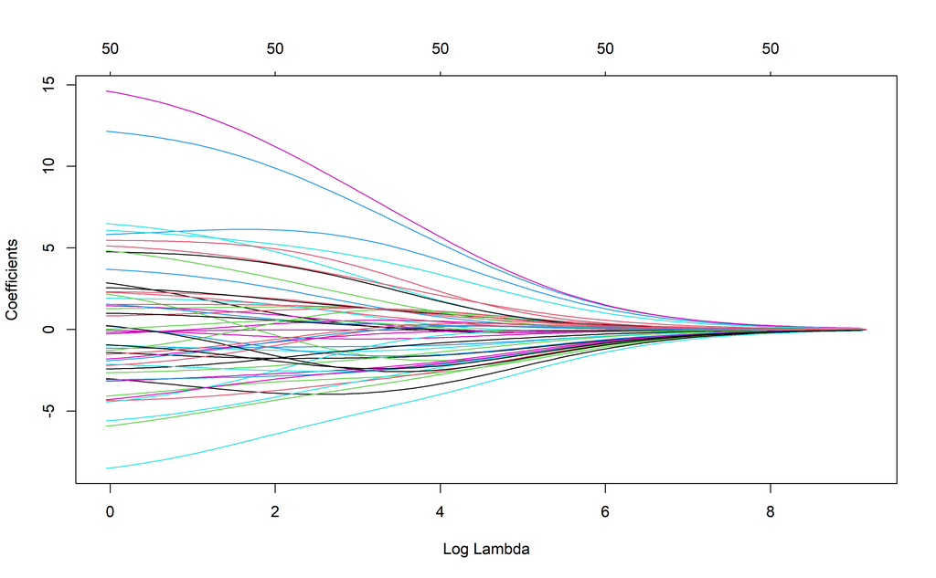

```r
# fit a ridge regression
ridge_fit <- glmnet(x = x, y = y, alpha = 0, standardize = TRUE, family = "gaussian")

# visualise the results
plot(ridge_fit, xvar = "lambda")
```

**Questions:**

1. As $\lambda$ increases, what happens to the coefficients estimates?
2. How do we chose the optimal tuning parameter, $\lambda$?
- Perform a 10-fold cross validation to determine the optimal value for lambda (hint: `cv.glmnet()`)
- Look at the results
- Identify the `lambda` that gives the lowest Mean-Squared Error (MSE)
  - What is the value of the MSE?
- How close are the model predictions? Are they better than the previous ones we’ve worked on?

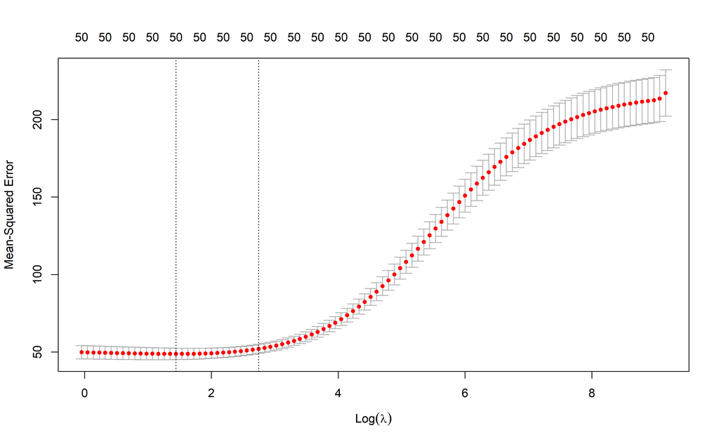

```r
# fit ridge regression
cv_ridge_fit <- cv.glmnet(x = x, y = y, alpha = 0, standardize = TRUE, family = "gaussian", type.measure = "mse", nfold = 10)

# visualise the results
plot(cv_ridge_fit)
```

```r
# lambdas
cv_ridge_fit$lambda.min
```

```
## [1] 4.225692
```

```r
cv_ridge_fit$lambda.1se
```

```
## [1] 15.5437
```

```r
log(cv_ridge_fit$lambda.min)
```

```
## [1] 1.441183
```

```r
log(cv_ridge_fit$lambda.1se)
```

```
## [1] 2.743655
```

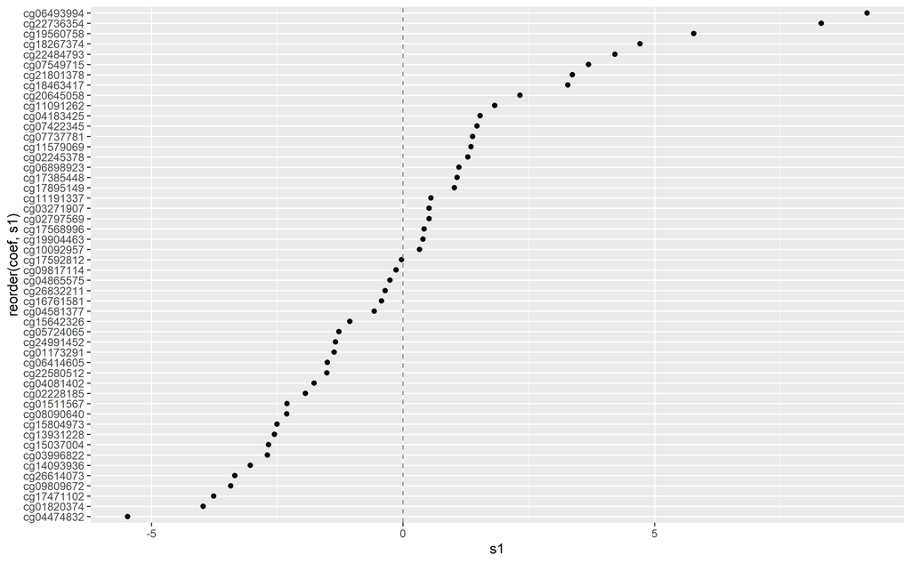

```r
# look at the coefficient values for the chosen lambdas
cv_ridge_coef <- coef(cv_ridge_fit, s = cv_ridge_fit$lambda.1se)
as.data.table(as.matrix(cv_ridge_coef), keep.rownames = "coef")[-1,] %>%
  ggplot(aes(s1, reorder(coef, s1))) +
  geom_point() +
  geom_vline(xintercept = 0, lty = 2, col = "gray55")
```

```r
# fitted values
cv_ridge_pred <- predict(object = cv_ridge_fit, s = cv_ridge_fit$lambda.1se, newx = x)
```

```r
# calculate the mean-squared error (MSE) for this model
mean((mdna_logodds$Age - cv_ridge_pred)^2)
```

```
## [1] 47.52361
```

```r
# try:

# correlation
cor(y, cv_ridge_pred[, 1], method = "spearman")
```

```
## [1] 0.8950561
```

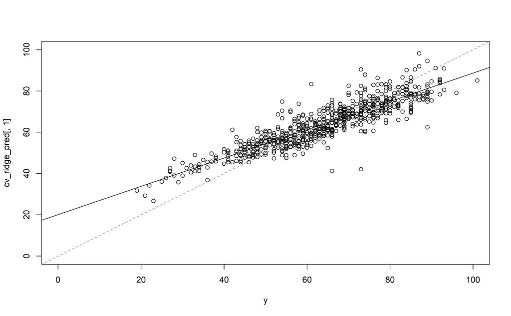

```r
# visualise the relation between fitted values and the real age of the patients
plot(y, cv_ridge_pred[, 1], xlim = c(0, 100), ylim = c(0, 100))
abline(lm(cv_ridge_pred[, 1] ~ y))
abline(0, 1, lty = 2, col = "gray55")
```

# LASSO regression

- Fit a LASSO regression using the `glmnet()` function
- Look at the results

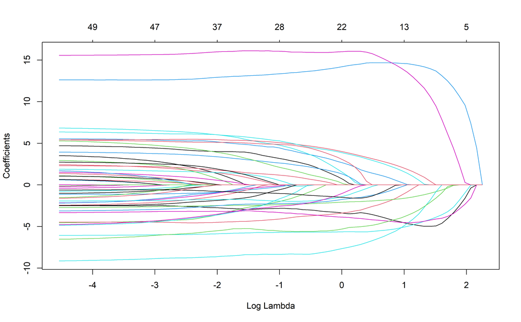

```r
# fit a LASSO regression
lasso_fit <- glmnet(x = x, y = y, alpha = 1, standardize = TRUE, family = "gaussian")

# visualise the results
plot(lasso_fit, xvar = "lambda")
```

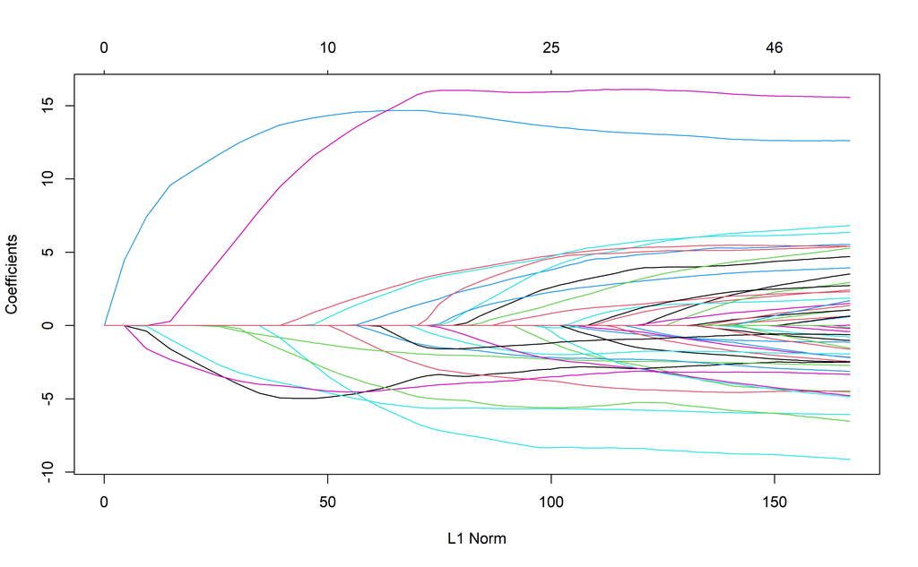

```r
# alternative
plot(lasso_fit)
```

**Question:** As $\lambda$ increases, this time what happens to the coefficients estimates?

- Perform a 10-fold cross validation for glmnet to determine the optimal value for lambda
- Look at the results
- Identify the $\lapbda_1$ that returns the lowest Mean-Squared Error (MSE)
  - What is the value of the MSE?
- Compare the results

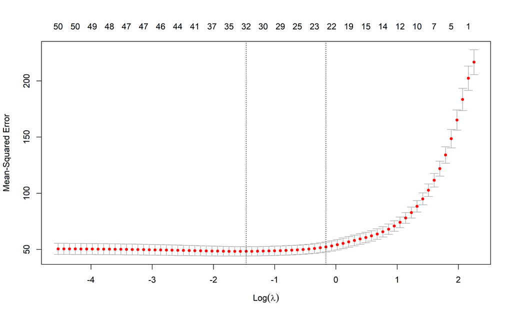

```r
# fit LASSO regression
cv_lasso_fit <- cv.glmnet(x = x, y = y, alpha = 1, standardize = TRUE, family = "gaussian", type.measure = "mse", nfold = 10)

# visualise the results
plot(cv_lasso_fit)
```

```r
# lambdas
cv_lasso_fit$lambda.min
```

```
## [1] 0.230819
```

```r
cv_lasso_fit$lambda.1se
```

```
## [1] 0.84904
```

```r
# log(cv_lasso_fit$lambda.min)
# log(cv_lasso_fit$lambda.1se)


# look at the coefficient values for the chosen lambdas
cv_lasso_coef <- coef(cv_lasso_fit, s = cv_lasso_fit$lambda.1se)

broom::tidy(cv_lasso_coef)
```

```
##            row column      value
## 1  (Intercept)     s1 84.6687343
## 2   cg01820374     s1 -3.2512936
## 3   cg19560758     s1  3.0304711
## 4   cg26614073     s1 -3.5122675
## 5   cg22736354     s1 13.9960477
## 6   cg07549715     s1  2.3142824
## 7   cg18463417     s1  1.3204451
## 8   cg11091262     s1  1.6502677
## 9   cg09809672     s1 -5.6645141
## 10  cg04183425     s1  0.1987443
## 11  cg02228185     s1 -2.1350140
## 12  cg20645058     s1  0.6126945
## 13  cg04474832     s1 -7.9120789
## 14  cg15804973     s1 -3.7916975
## 15  cg22484793     s1  3.5887372
## 16  cg17471102     s1 -5.4671080
## 17  cg13931228     s1 -1.6374189
## 18  cg06493994     s1 15.9389764
## 19  cg21801378     s1  4.2591639
## 20  cg03996822     s1 -1.9164854
## 21  cg18267374     s1  4.1189963
## 22  cg15037004     s1 -1.4743240
## 23  cg01511567     s1 -1.4044481
```

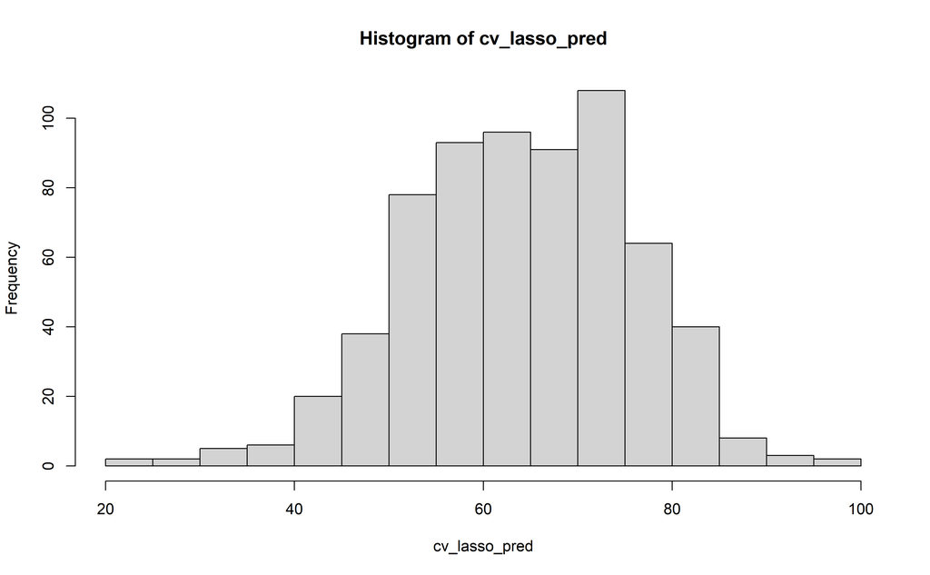

```r
# fitted values
cv_lasso_pred <- predict(object = cv_lasso_fit, s = cv_lasso_fit$lambda.1se, newx = x)
hist(cv_lasso_pred)
```

```r
# calculate the mean-squared error (MSE) for this model
mean((mdna_logodds$Age - cv_lasso_pred)^2)
```

```
## [1] 47.06563
```

```r
# try:

# correlation
cor(y, cv_lasso_pred[, 1], method = "spearman")
```

```
## [1] 0.8886194
```

# Try different values of `alpha`

- Play around with alpha, and see if you can estimate a lower value for the MSE
  - try `alpha = 0.5`
- Compare the results with the Ridge and LASSO regression models

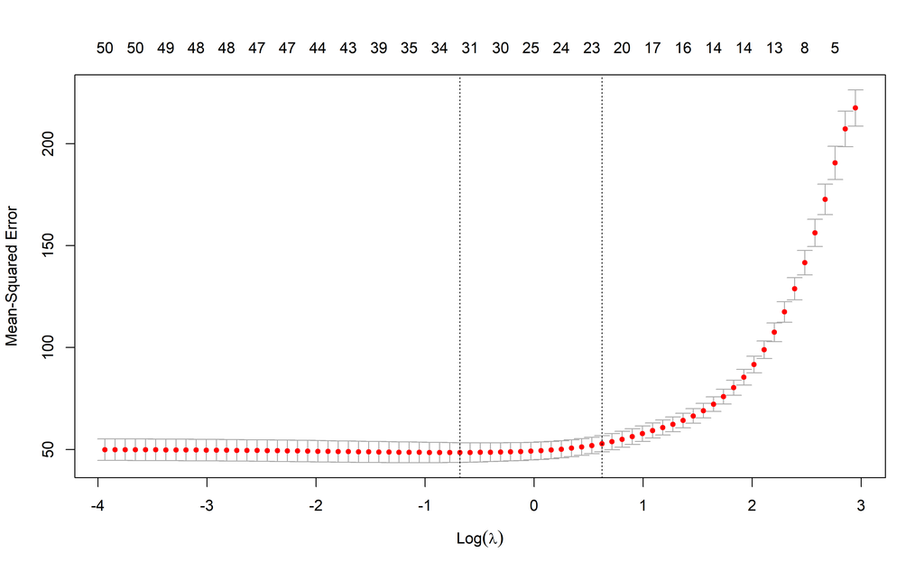

```r
# fit the cross-validation model
cv_fit_a0.5 <- cv.glmnet(x = x, y = y, alpha = 0.5, standardize = TRUE, family = "gaussian", type.measure = "mse", nfold = 10)
plot(cv_fit_a0.5)
```

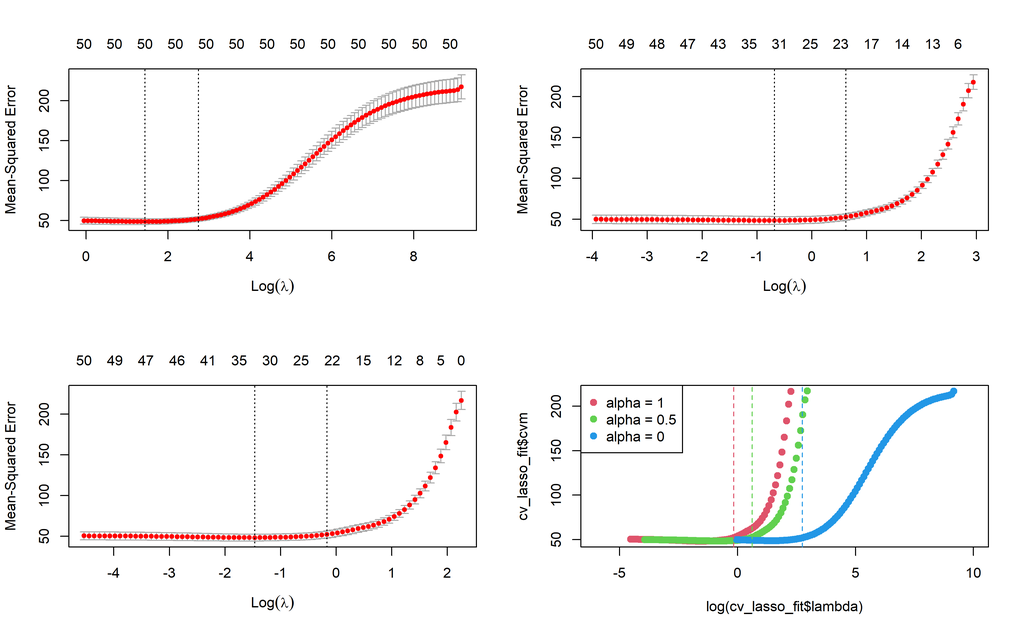

```r
# try:

par(mfrow = c(2, 2))
plot(cv_ridge_fit)
plot(cv_fit_a0.5)
plot(cv_lasso_fit)
plot(log(cv_lasso_fit$lambda), cv_lasso_fit$cvm, col = 2, pch = 19, xlim = c(-6, 10))
points(log(cv_fit_a0.5$lambda), cv_fit_a0.5$cvm, col = 3, pch = 19)
points(log(cv_ridge_fit$lambda), cv_ridge_fit$cvm, col = 4, pch = 19)
legend("topleft", legend = c("alpha = 1", "alpha = 0.5", "alpha = 0"), pch = 19, col = 2:4)
abline(v = log(c(cv_ridge_fit$lambda.1se, cv_fit_a0.5$lambda.1se, cv_lasso_fit$lambda.1se)), col = 4:2, lty = 2)
```

```r
par(mfrow = c(1,1))
```

Rather than “guessing” the best value of alpha, the best approach is to loop through a sequence of determined values…

- Loop through a 10-fold cross validation to determine the optimal value of $\lambda$ at different values of $\alpha$

```r
# alphas to try
alphas <- seq(0, 1, 0.01)

# loop sequence to generate the results at each alpha
cv_fit_en <- lapply(seq(alphas), function(i) cv.glmnet(x = x, y = y, alpha = alphas[i], standardize = TRUE, family = "gaussian", type.measure = "mse", nfold = 10))
```

```r
# alternative with a for loop:
# cv_fit_en <- list()
# for(i in seq(alphas)) {
#   cv_fit_en[[i]] <- cv.glmnet(x = x, y = y, alpha = alphas[i], standardize = TRUE, family = "gaussian", type.measure = "mse", nfold = 10)
# }
```

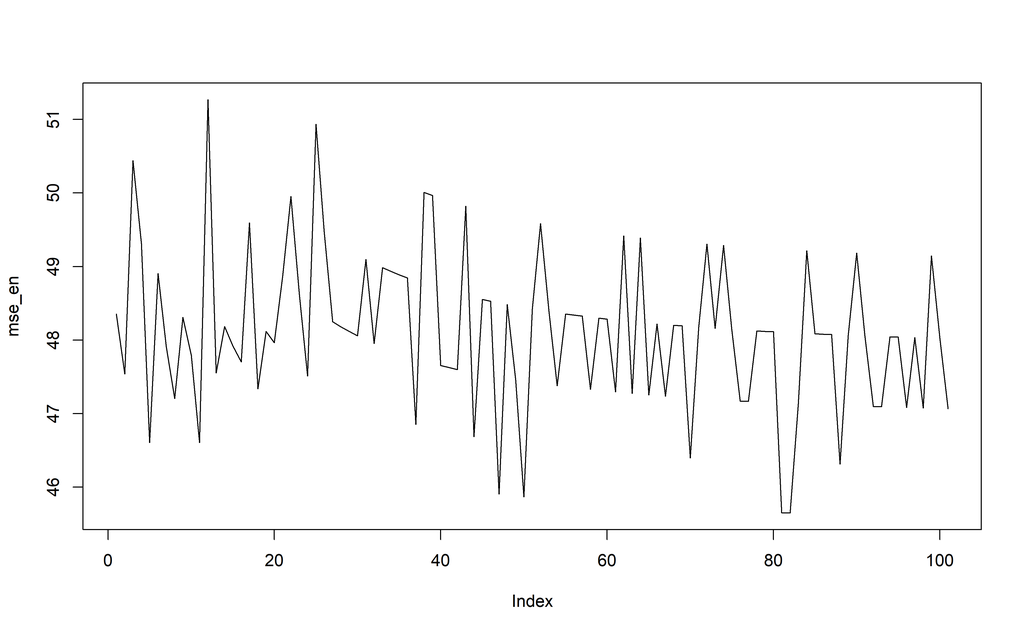

```r
# look at the optimal values for lambda
vec_lambda_en <- sapply(seq_along(cv_fit_en), function(i) cv_fit_en[[i]]$lambda.1se)


# loop to estimate the fitted values of each 10-fold cross validated model
pred_en <- lapply(seq_along(cv_fit_en), function(i) predict(cv_fit_en[[i]], s = vec_lambda_en[i], newx = x))


# estimate the MSE of each model
mse_en <- sapply(seq_along(cv_fit_en), function(i) mean((mdna_logodds$Age - pred_en[[i]])^2))


# visualise the results
plot(mse_en, type = "l")
```

```r
# minimum MSE value
min(mse_en)
```

```
## [1] 45.64728
```

```r
# minimum MSE position
which.min(mse_en)
```

```
## [1] 82
```

```r
# select the model with lower MSE
cv_fit_elastic_net <- cv_fit_en[[which.min(mse_en)]]


# lambda
cv_fit_elastic_net$lambda.min
```

```
## [1] 0.2849618
```

```r
cv_fit_elastic_net$lambda.1se
```

```
## [1] 0.870232
```

```r
# look at the coefficient values for the lambda
cv_fit_elastic_net_coef <- coef(cv_fit_elastic_net, s = cv_fit_elastic_net$lambda.1se)
broom::tidy(cv_fit_elastic_net_coef)
```

```
##            row column      value
## 1  (Intercept)     s1 82.3321292
## 2   cg14093936     s1 -0.3972895
## 3   cg01820374     s1 -3.1740277
## 4   cg19560758     s1  3.5725752
## 5   cg26614073     s1 -3.6144423
## 6   cg22736354     s1 13.6746196
## 7   cg07549715     s1  3.1000108
## 8   cg18463417     s1  1.9070566
## 9   cg11091262     s1  1.9087560
## 10  cg09809672     s1 -5.6319975
## 11  cg04183425     s1  0.5017580
## 12  cg02228185     s1 -2.2149891
## 13  cg20645058     s1  0.9434220
## 14  cg04474832     s1 -8.0701371
## 15  cg15804973     s1 -3.6370580
## 16  cg22484793     s1  4.0658898
## 17  cg17471102     s1 -5.5092993
## 18  cg13931228     s1 -1.8302376
## 19  cg06493994     s1 15.6865877
## 20  cg21801378     s1  4.4739329
## 21  cg03996822     s1 -2.0891743
## 22  cg18267374     s1  4.3586665
## 23  cg15037004     s1 -1.9126507
## 24  cg01511567     s1 -1.3689806
```

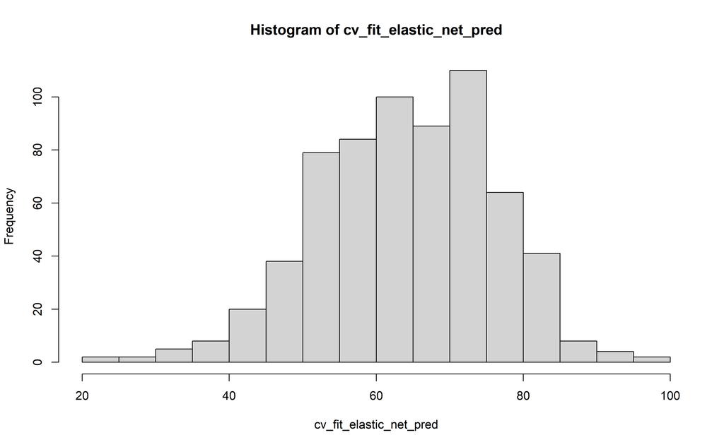

```r
# fitted values
cv_fit_elastic_net_pred <- predict(cv_fit_elastic_net, s = cv_fit_elastic_net$lambda.1se, newx = x)

hist(cv_fit_elastic_net_pred)
```

# Extending the analysis

- To streamline this analysis you can apply the [*caret*](https://cran.r-project.org/web/packages/caret/index.html) package